# REPORTE: Análisis de Expresión Diferencial

García Carlos

2025-02-09

Domingo 09 de Febrero del 2025

*García González Carlos*

# Introducción

El **cáncer** se origina cuando las células en alguna parte del cuerpo comienzan a crecer sin control. Existen muchos tipos de cáncer. Las células en casi cualquier parte del cuerpo pueden convertirse en cáncer.

Las **leucemias** son cánceres que se origina en las células que normalmente madurarían hacia los diferentes tipos de células sanguíneas. Con más frecuencia, la leucemia se origina en formas tempranas de glóbulos blancos, pero algunas leucemias comienzan en otros tipos de células sanguíneas. Existen varios tipos de leucemia que se dividen basándose principalmente en si la leucemia es **aguda** (rápido crecimiento) o **crónica** (crecimiento más lento), y si se inicia en células mieloides o células linfoides.

La **leucemia mieloide aguda** (**AML**, por sus siglas en inglés) se inicia en la médula ósea, pero con más frecuencia también pasa rápidamente a la sangre. Algunas veces se propaga a otras partes del cuerpo, incluyendo los ganglios linfáticos, el hígado, el bazo, el sistema nervioso central y los testículos.

# Análisi de los resultados obtenidos

El código utilizado para obtener los resultados puede ser consultado en el siguiente path:

```r
 # Proyecto_Bioinformatica/Code/Analisis_expresion_diferencial.Rmd
```

### Data

Los datos de este análisis son del proyecto de [**Leucemia Mieloide Aguda (LAML)**](https://portal.gdc.cancer.gov/projects/TCGA-LAML) provenientes de [**The Cancer Genome Atlas (TCGA)**](https://www.cancer.gov/ccg/research/genome-sequencing/tcga).

Dichos datos estaban constituidos por 178 muestras provinientes de diferentes pacientes, en los cuales se observo la expresión de 63 856 genes.

Para ver más a detalle los pasos que se siguieron y la estrategia de limpieza y normalización de datos, se puede consultar el código cuyo path se encuentra al inicio de esta sección.

### Resultados

Hablaremos más a detalle de los resultados obtenidos de tres graficas en concreto: Heatmap, MA plot y volcanoplot:

#### Volcanoplot

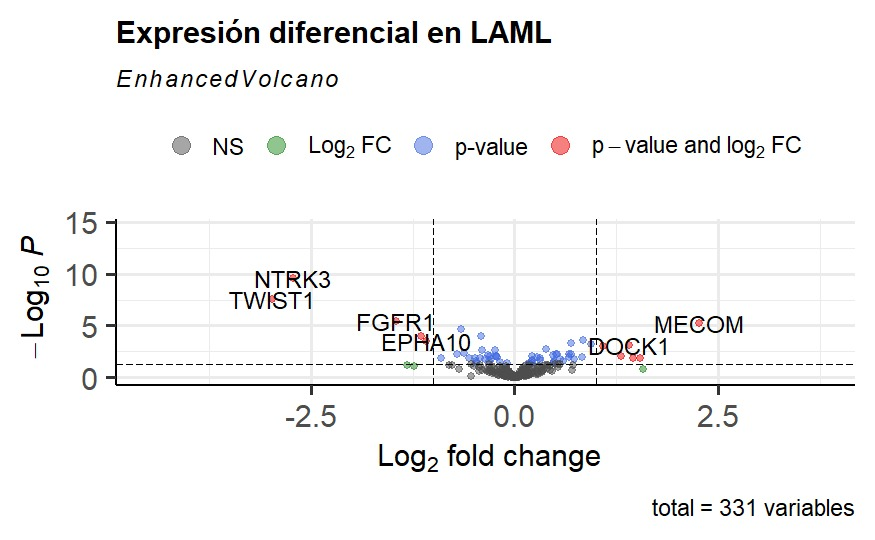

**Figura 1.** Volcano plot de los genes de diferenciación de células mieloides diferencialmente expresados en LAML.

#### Hetmap

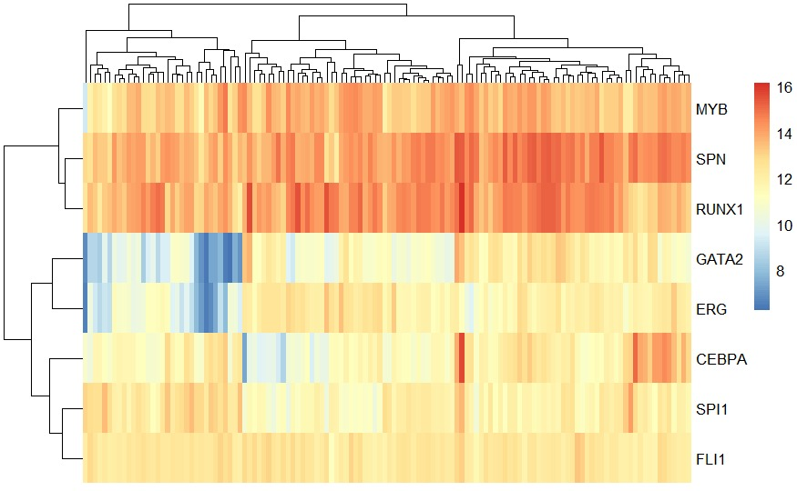

**Figura 2.** Heatmap de la expresión diferencial de genes en LAML. El color indica el nivel de expresión, con rojo para alta y azul para baja expresión.

#### MA plot

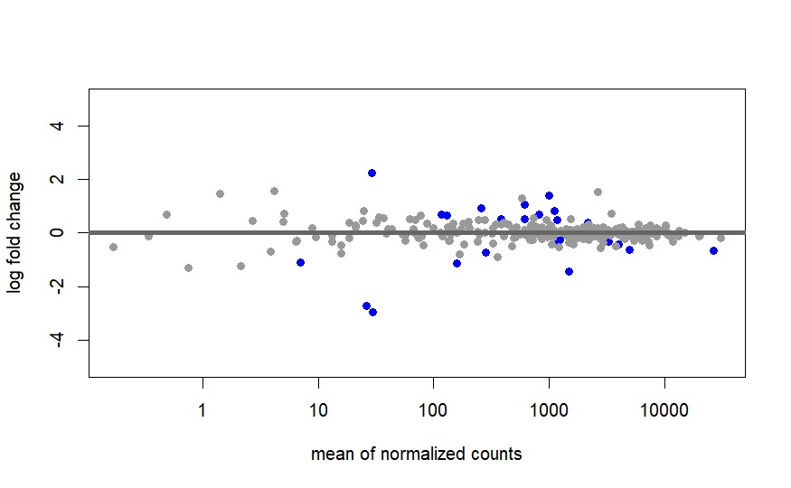

**Figura 3.** MA plot de la expresión diferencial en LAML. Se muestra el log₂ del cambio de expresión frente a la media de cuentas normalizadas, destacando en azul los genes diferencialmente expresados.

#### Box plot

Además de ver la expresión diferencial en general, se analizo un gen en particular, el cual fue **SPN**, quien codifíca para **CD43** ya que una alta expresión de este gen se asocia con la malignidad de los cánceres.

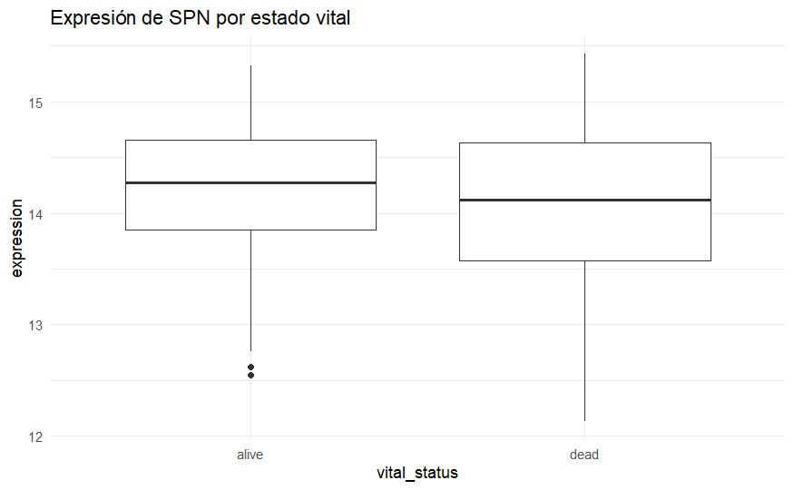

#### PCA

Por ultímo se realizo un PCA en el análisis de expresión diferencial en LAML ya que es una estrategia útil porque nos permite reducir la dimensionalidad de los datos y visualizar su variabilidad de manera más comprensible. Esto facilita la identificación de posibles agrupaciones entre las muestras según su estado vital, lo que puede revelar diferencias biológicas relevantes.

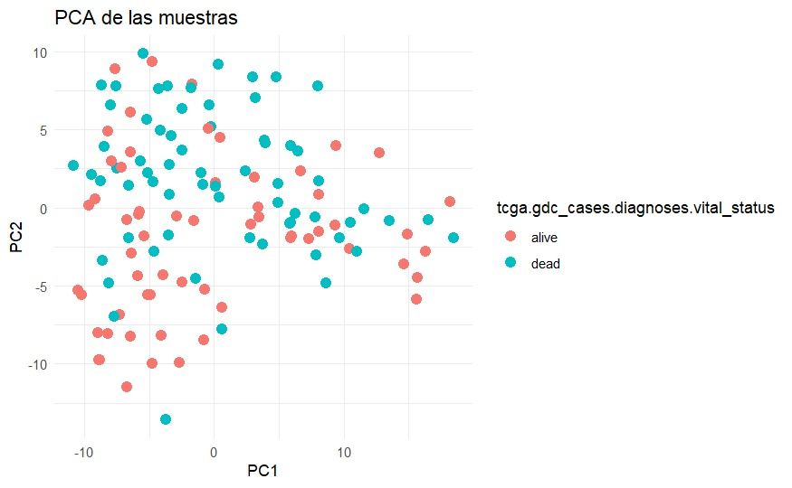

**Figura 5.** Se muestra la distribución de las muestras en el espacio de los primeros dos componentes principales (PC1 y PC2), con los puntos coloreados según el estado vital de los individuos..

#### Resultados Explicados

[output not shown]

En la leucemia mieloide aguda (LMA), la sobreexpresión de ciertos genes está estrechamente relacionada con la desregulación de la hematopoyesis normal, lo que conduce a una proliferación incontrolada de células mieloides inmaduras en la médula ósea. Este fenómeno puede ocurrir por mutaciones en factores de transcripción clave, como RUNX1, SPI1 y GATA2, que regulan la diferenciación de las células hematopoyéticas. Cuando estos genes se sobreexpresan o presentan alteraciones en su función, pueden impedir la maduración celular normal y promover la acumulación de blastos inmaduros en la médula ósea y la sangre periférica. Adicionalmente, la sobreexpresión de genes oncogénicos como MEF2C o ERG puede favorecer la proliferación celular al activar vías de señalización que inhiben la apoptosis y promueven la supervivencia de las células leucémicas.

## Referencias

- Recount 3 https://bioconductor.org/packages/release/bioc/html/recount3.html
- Bioconductor https://bioconductor.org/
- TCGA-LAML project https://bioconductor.org/